# Annexes : Plot And Explain

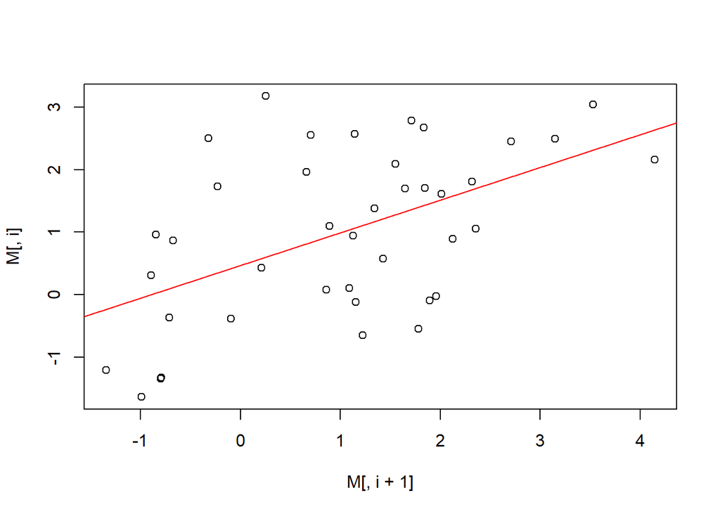

```
##
## Call:
## lm(formula = M[, i] ~ M[, i + 1])
##
## Residuals:
##     Min      1Q  Median      3Q     Max
## -2.2498 -1.0385  0.1551  0.8139  3.0370
##
## Coefficients:
##             Estimate Std. Error t value Pr(>|t|)
## (Intercept)   0.7962     0.2530   3.147   0.0032 **
## M[, i + 1]    0.2245     0.1433   1.566   0.1256
## ---
## Signif. codes:  0 '***' 0.001 '**' 0.01 '*' 0.05 '.' 0.1 ' ' 1
##
## Residual standard error: 1.311 on 38 degrees of freedom
## Multiple R-squared:  0.06065,    Adjusted R-squared:  0.03593
## F-statistic: 2.453 on 1 and 38 DF,  p-value: 0.1256
```

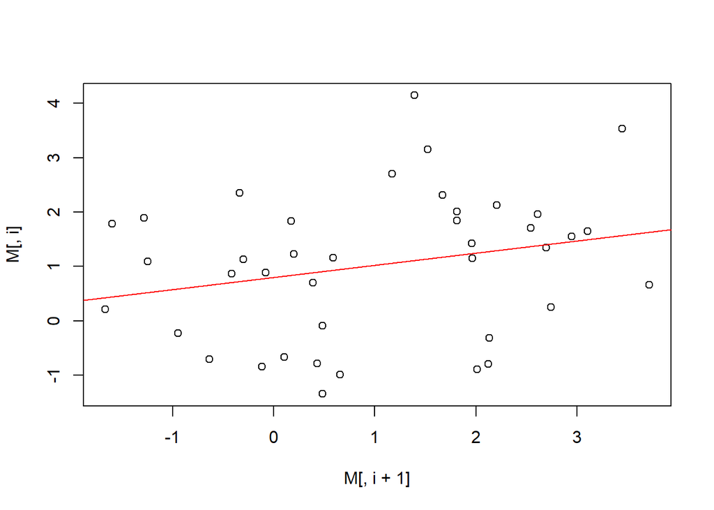

```
##
## Call:
## lm(formula = M[, i] ~ M[, i + 1])
##
## Residuals:
##      Min       1Q   Median       3Q      Max
## -2.52194 -0.97598 -0.02078  1.15499  2.90645
##
## Coefficients:
##             Estimate Std. Error t value Pr(>|t|)
## (Intercept)   1.0265     0.2350   4.369 9.33e-05 ***
## M[, i + 1]   -0.1441     0.2533  -0.569    0.573
## ---
## Signif. codes:  0 '***' 0.001 '**' 0.01 '*' 0.05 '.' 0.1 ' ' 1
##
## Residual standard error: 1.477 on 38 degrees of freedom
## Multiple R-squared:  0.008442,   Adjusted R-squared:  -0.01765
## F-statistic: 0.3235 on 1 and 38 DF,  p-value: 0.5729
```

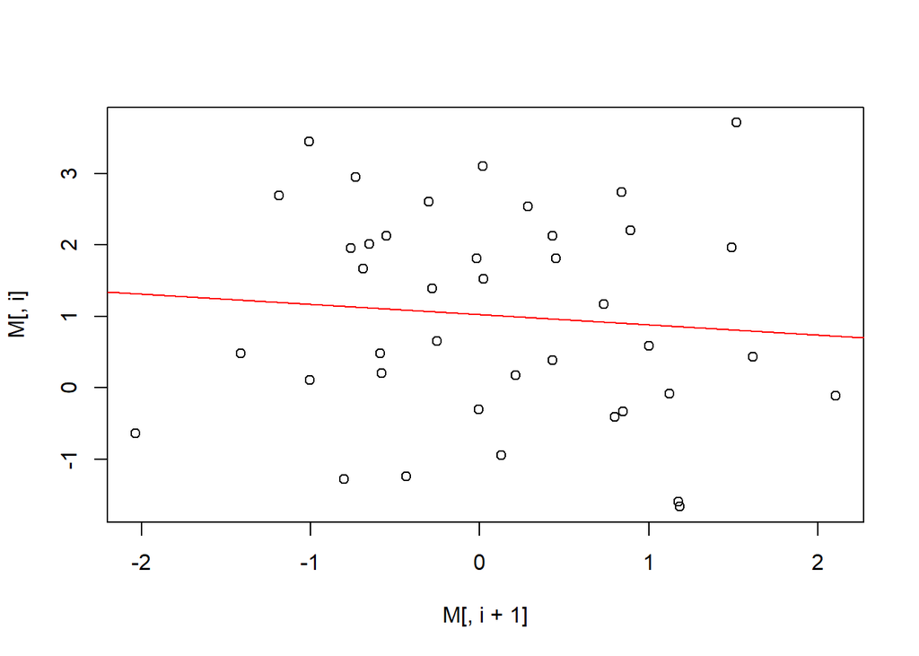

```
##
## Call:
## lm(formula = M[, i] ~ M[, i + 1])
##
## Residuals:
##     Min      1Q  Median      3Q     Max
## -2.0014 -0.6631 -0.1229  0.8054  1.7945
##
## Coefficients:
##             Estimate Std. Error t value Pr(>|t|)
## (Intercept)   0.1055     0.1436   0.735   0.4668
## M[, i + 1]    0.2460     0.1363   1.804   0.0791 .
## ---
## Signif. codes:  0 '***' 0.001 '**' 0.01 '*' 0.05 '.' 0.1 ' ' 1
##
## Residual standard error: 0.9079 on 38 degrees of freedom
## Multiple R-squared:  0.07893,    Adjusted R-squared:  0.05469
## F-statistic: 3.256 on 1 and 38 DF,  p-value: 0.07909
```

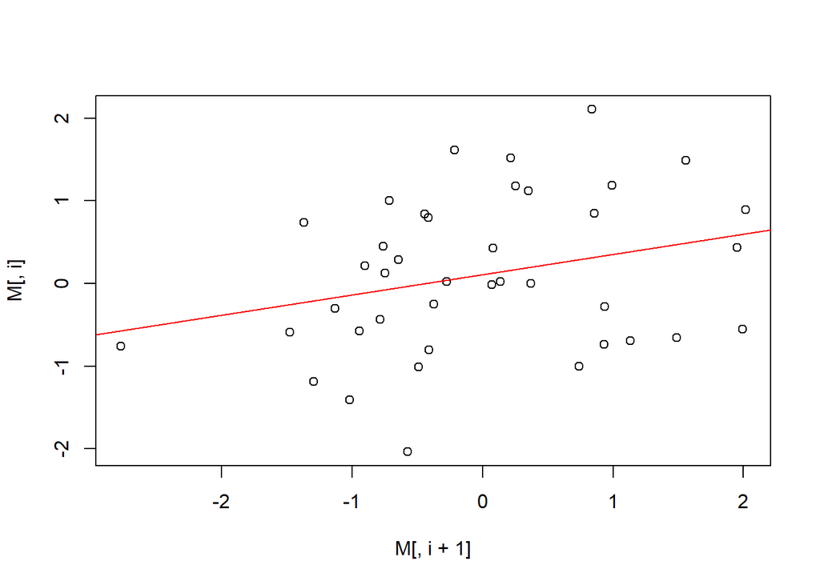

```
##
## Call:
## lm(formula = M[, i] ~ M[, i + 1])
##
## Residuals:
##     Min      1Q  Median      3Q     Max
## -2.7407 -0.6603 -0.2044  0.7848  2.0829
##
## Coefficients:
##              Estimate Std. Error t value Pr(>|t|)
## (Intercept) -0.009926   0.169119  -0.059    0.954
## M[, i + 1]  -0.153464   0.159488  -0.962    0.342
##
## Residual standard error: 1.067 on 38 degrees of freedom
## Multiple R-squared:  0.02379,    Adjusted R-squared:  -0.001904
## F-statistic: 0.9259 on 1 and 38 DF,  p-value: 0.342
```

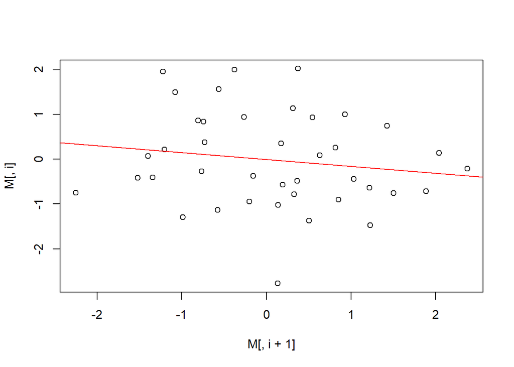

```
##
## Call:
## lm(formula = M[, i] ~ M[, i + 1])
##
## Residuals:
##      Min       1Q   Median       3Q      Max
## -2.33465 -0.81477  0.07198  0.73778  2.31048
##
## Coefficients:
##             Estimate Std. Error t value Pr(>|t|)
## (Intercept)  0.05882    0.17655   0.333    0.741
## M[, i + 1]   0.03801    0.15628   0.243    0.809
##
## Residual standard error: 1.085 on 38 degrees of freedom
## Multiple R-squared:  0.001554,   Adjusted R-squared:  -0.02472
## F-statistic: 0.05914 on 1 and 38 DF,  p-value: 0.8092
```

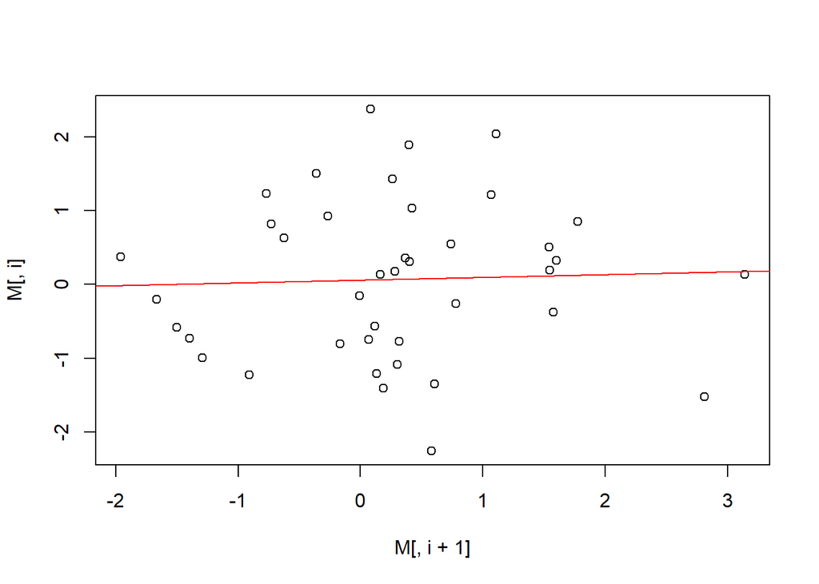

```
##
## Call:
## lm(formula = M[, i] ~ M[, i + 1])
##
## Residuals:
##      Min       1Q   Median       3Q      Max
## -2.36282 -0.48847  0.01191  0.44042  2.98523
##
## Coefficients:
##             Estimate Std. Error t value Pr(>|t|)
## (Intercept)   0.2434     0.1806   1.348    0.186
## M[, i + 1]   -0.1150     0.1693  -0.679    0.501
##
## Residual standard error: 1.119 on 38 degrees of freedom
## Multiple R-squared:  0.012,  Adjusted R-squared:  -0.014
## F-statistic: 0.4614 on 1 and 38 DF,  p-value: 0.5011
```

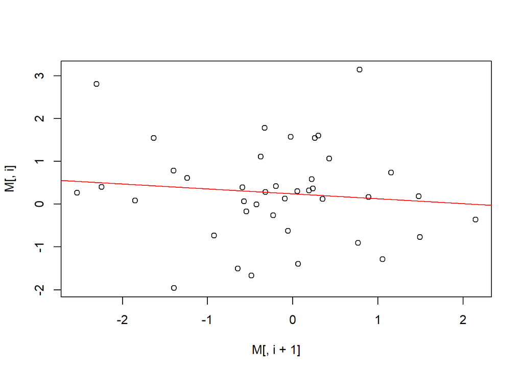

```
##
## Call:
## lm(formula = M[, i] ~ M[, i + 1])
##
## Residuals:
##      Min       1Q   Median       3Q      Max
## -2.29319 -0.42747  0.06047  0.51572  2.39245
##
## Coefficients:
##             Estimate Std. Error t value Pr(>|t|)
## (Intercept) -0.21181    0.16945  -1.250    0.219
## M[, i + 1]  -0.04384    0.17828  -0.246    0.807
##
## Residual standard error: 1.072 on 38 degrees of freedom
## Multiple R-squared:  0.001589,   Adjusted R-squared:  -0.02468
## F-statistic: 0.06048 on 1 and 38 DF,  p-value: 0.8071
```

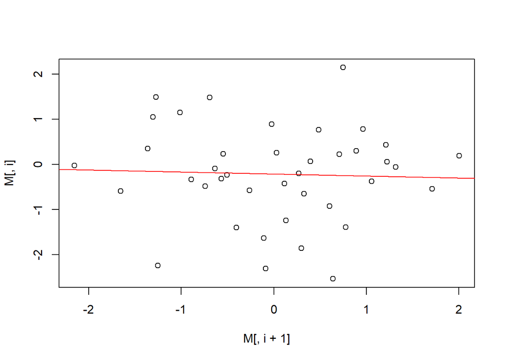

```
##
## Call:
## lm(formula = M[, i] ~ M[, i + 1])
##
## Residuals:
##      Min       1Q   Median       3Q      Max
## -1.98913 -0.68731  0.09899  0.68115  1.81587
##
## Coefficients:
##             Estimate Std. Error t value Pr(>|t|)
## (Intercept)  0.02269    0.15367   0.148    0.883
## M[, i + 1]  -0.13708    0.16986  -0.807    0.425
##
## Residual standard error: 0.9668 on 38 degrees of freedom
## Multiple R-squared:  0.01685,    Adjusted R-squared:  -0.009022
## F-statistic: 0.6513 on 1 and 38 DF,  p-value: 0.4247
```

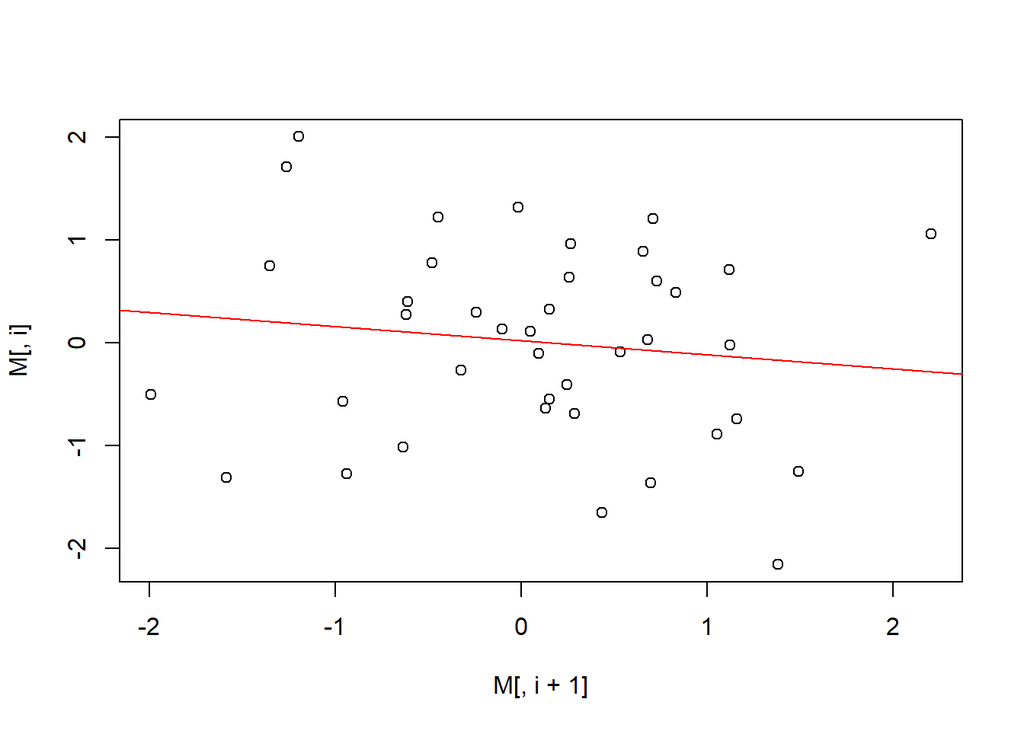

```
##
## Call:
## lm(formula = M[, i] ~ M[, i + 1])
##
## Residuals:
##     Min      1Q  Median      3Q     Max
## -2.2510 -0.5917  0.1410  0.6621  1.7789
##
## Coefficients:
##             Estimate Std. Error t value Pr(>|t|)
## (Intercept)   0.1111     0.1433   0.775    0.443
## M[, i + 1]    0.2004     0.1473   1.361    0.182
##
## Residual standard error: 0.9016 on 38 degrees of freedom
## Multiple R-squared:  0.04647,    Adjusted R-squared:  0.02137
## F-statistic: 1.852 on 1 and 38 DF,  p-value: 0.1816
```

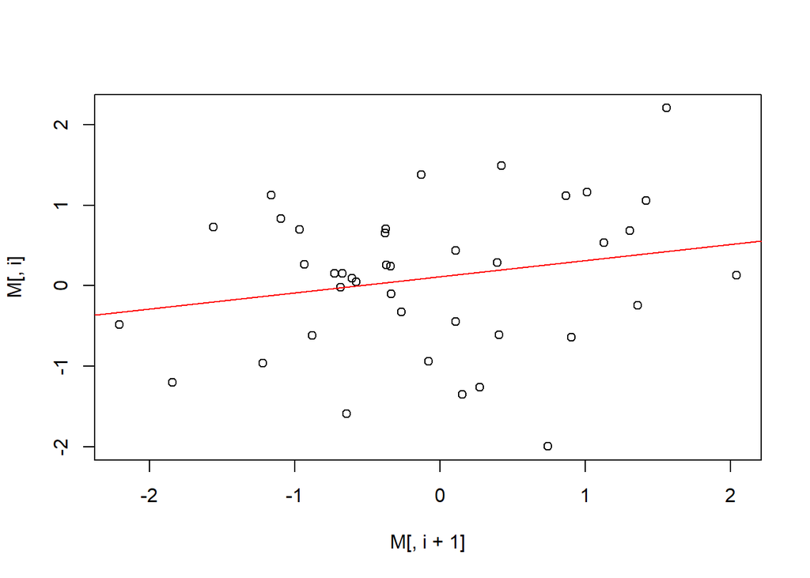

```
##
## Call:
## lm(formula = M[, i] ~ M[, i + 1])
##
## Residuals:
##     Min      1Q  Median      3Q     Max
## -2.0625 -0.6705 -0.1828  0.6356  2.2107
##
## Coefficients:
##             Estimate Std. Error t value Pr(>|t|)
## (Intercept) -0.10659    0.15766  -0.676    0.503
## M[, i + 1]   0.09037    0.16713   0.541    0.592
##
## Residual standard error: 0.9894 on 38 degrees of freedom
## Multiple R-squared:  0.007634,   Adjusted R-squared:  -0.01848
## F-statistic: 0.2923 on 1 and 38 DF,  p-value: 0.5919
```

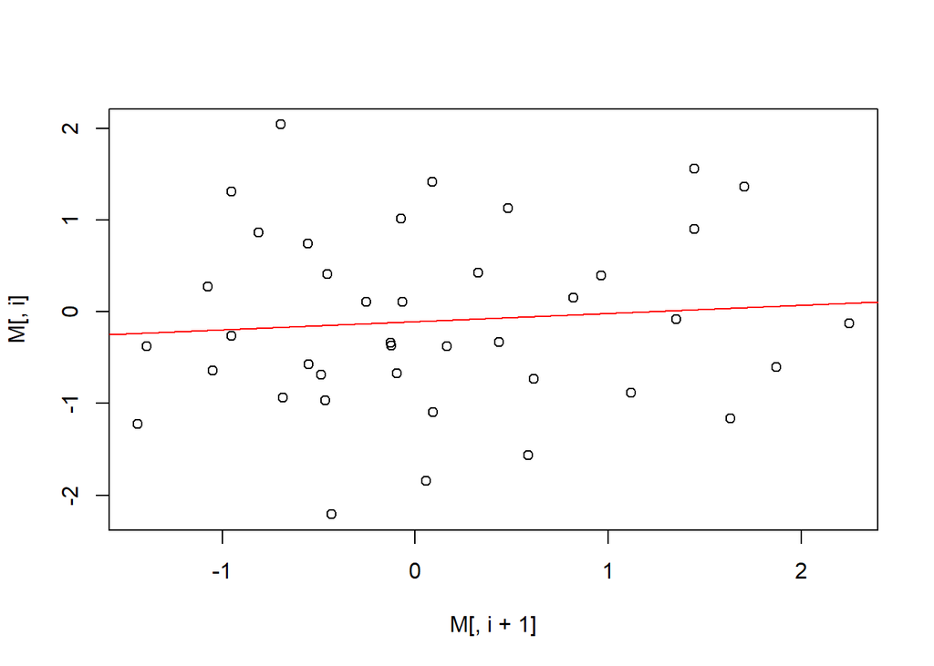

```
##
## Call:
## lm(formula = M[, i] ~ M[, i + 1])
##
## Residuals:
##     Min      1Q  Median      3Q     Max
## -1.4546 -0.6955 -0.2185  0.5800  2.3481
##
## Coefficients:
##             Estimate Std. Error t value Pr(>|t|)
## (Intercept)  0.09749    0.14879   0.655    0.516
## M[, i + 1]  -0.21789    0.15659  -1.391    0.172
##
## Residual standard error: 0.9368 on 38 degrees of freedom
## Multiple R-squared:  0.04848,    Adjusted R-squared:  0.02344
## F-statistic: 1.936 on 1 and 38 DF,  p-value: 0.1722
```

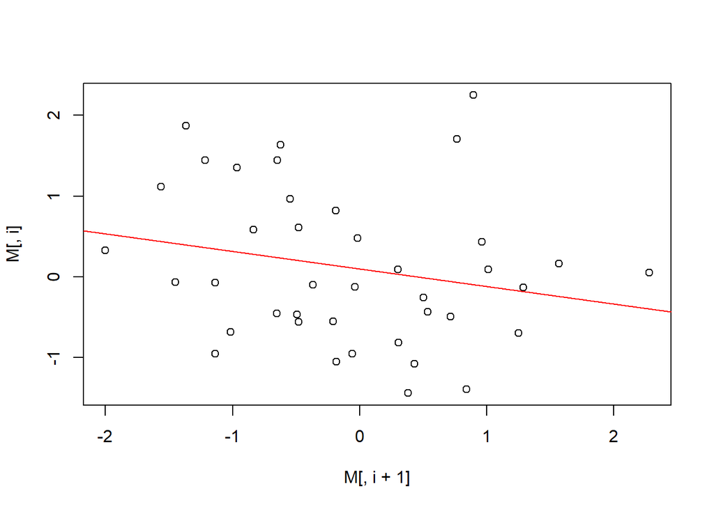

```
##
## Call:
## lm(formula = M[, i] ~ M[, i + 1])
##
## Residuals:
##      Min       1Q   Median       3Q      Max
## -1.82811 -0.63228  0.03353  0.70454  2.45192
##
## Coefficients:
##             Estimate Std. Error t value Pr(>|t|)
## (Intercept) -0.08981    0.14834  -0.605    0.548
## M[, i + 1]  -0.24592    0.15089  -1.630    0.111
##
## Residual standard error: 0.9382 on 38 degrees of freedom
## Multiple R-squared:  0.06533,    Adjusted R-squared:  0.04074
## F-statistic: 2.656 on 1 and 38 DF,  p-value: 0.1114
```

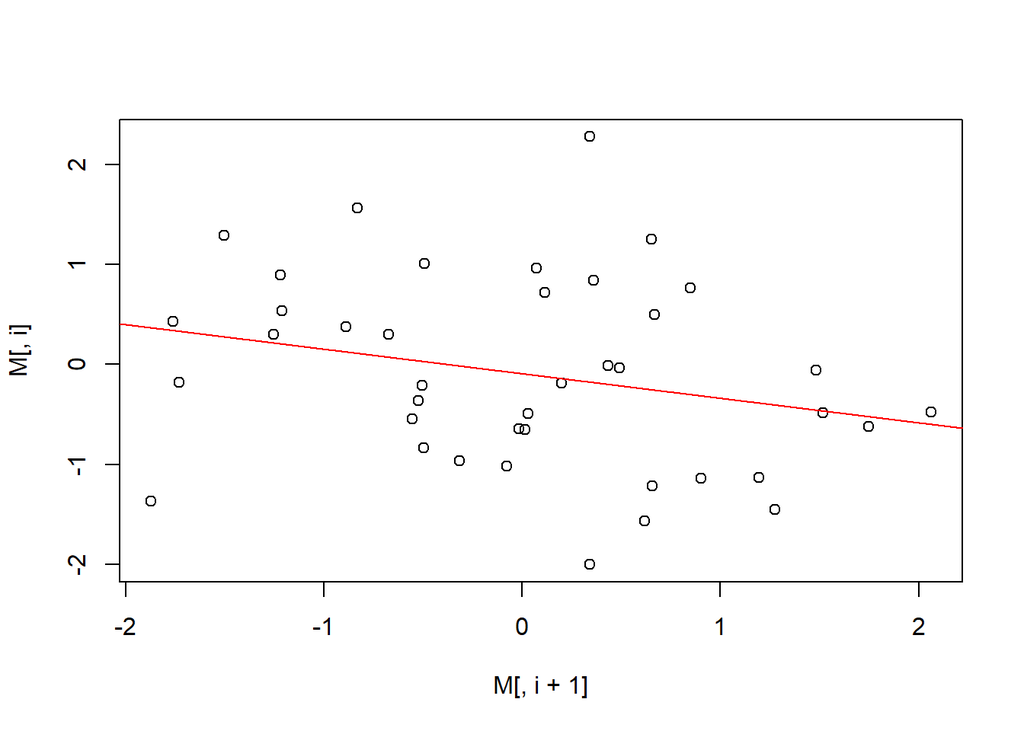

```
##
## Call:
## lm(formula = M[, i] ~ M[, i + 1])
##
## Residuals:
##      Min       1Q   Median       3Q      Max
## -1.70641 -0.72060  0.05097  0.56851  2.00536
##
## Coefficients:
##             Estimate Std. Error t value Pr(>|t|)
## (Intercept) -0.01045    0.15834  -0.066    0.948
## M[, i + 1]   0.17773    0.19293   0.921    0.363
##
## Residual standard error: 0.9976 on 38 degrees of freedom
## Multiple R-squared:  0.02185,    Adjusted R-squared:  -0.003896
## F-statistic: 0.8487 on 1 and 38 DF,  p-value: 0.3627
```

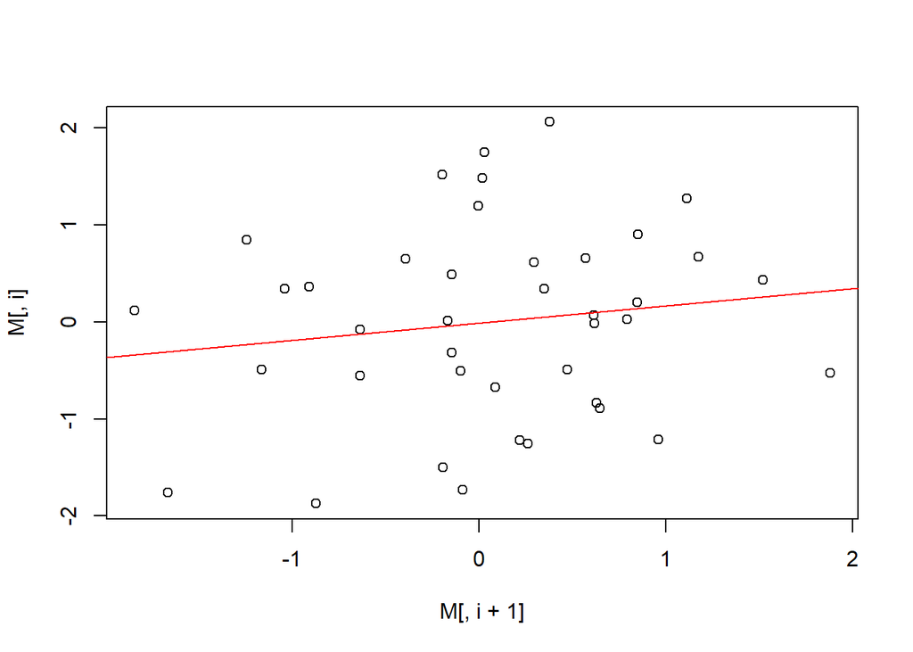

```
##
## Call:
## lm(formula = M[, i] ~ M[, i + 1])
##
## Residuals:
##      Min       1Q   Median       3Q      Max
## -1.85838 -0.53030  0.05489  0.51810  1.58693
##
## Coefficients:
##             Estimate Std. Error t value Pr(>|t|)
## (Intercept)  0.09097    0.12710   0.716   0.4785
## M[, i + 1]   0.28283    0.14830   1.907   0.0641 .
## ---
## Signif. codes:  0 '***' 0.001 '**' 0.01 '*' 0.05 '.' 0.1 ' ' 1
##
## Residual standard error: 0.8013 on 38 degrees of freedom
## Multiple R-squared:  0.08736,    Adjusted R-squared:  0.06334
## F-statistic: 3.637 on 1 and 38 DF,  p-value: 0.06407
```

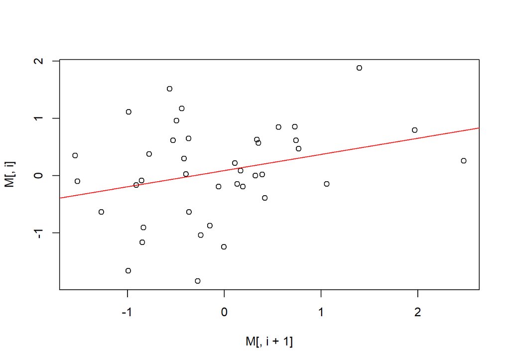

```
##
## Call:
## lm(formula = M[, i] ~ M[, i + 1])
##
## Residuals:
##      Min       1Q   Median       3Q      Max
## -1.45535 -0.60667 -0.05161  0.53380  2.39441
##
## Coefficients:
##             Estimate Std. Error t value Pr(>|t|)
## (Intercept) -0.08804    0.13938  -0.632    0.531
## M[, i + 1]   0.12424    0.14558   0.853    0.399
##
## Residual standard error: 0.8683 on 38 degrees of freedom
## Multiple R-squared:  0.01881,    Adjusted R-squared:  -0.007016
## F-statistic: 0.7283 on 1 and 38 DF,  p-value: 0.3988
```

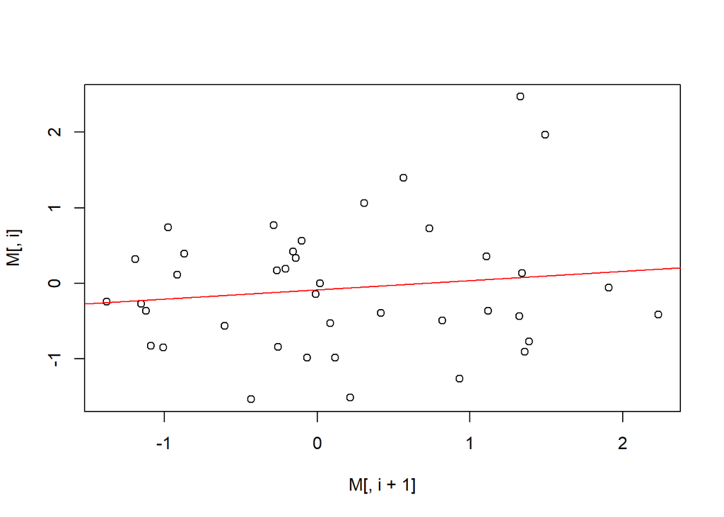

```
##
## Call:
## lm(formula = M[, i] ~ M[, i + 1])
##
## Residuals:
##     Min      1Q  Median      3Q     Max
## -1.5281 -0.7011 -0.1199  0.8249  2.2381
##
## Coefficients:
##             Estimate Std. Error t value Pr(>|t|)
## (Intercept)   0.1798     0.1492   1.205    0.236
## M[, i + 1]   -0.1957     0.1334  -1.467    0.151
##
## Residual standard error: 0.9413 on 38 degrees of freedom
## Multiple R-squared:  0.05359,    Adjusted R-squared:  0.02868
## F-statistic: 2.152 on 1 and 38 DF,  p-value: 0.1506
```

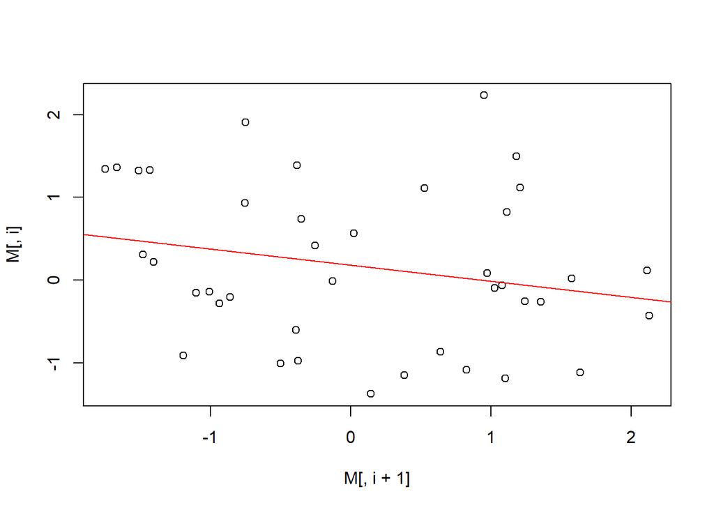

```
##
## Call:
## lm(formula = M[, i] ~ M[, i + 1])
##
## Residuals:
##      Min       1Q   Median       3Q      Max
## -1.79203 -0.99784 -0.05654  0.92751  2.12366
##
## Coefficients:
##             Estimate Std. Error t value Pr(>|t|)
## (Intercept)  0.09214    0.18088   0.509    0.613
## M[, i + 1]  -0.15168    0.19082  -0.795    0.432
##
## Residual standard error: 1.135 on 38 degrees of freedom
## Multiple R-squared:  0.01636,    Adjusted R-squared:  -0.009529
## F-statistic: 0.6319 on 1 and 38 DF,  p-value: 0.4316
```

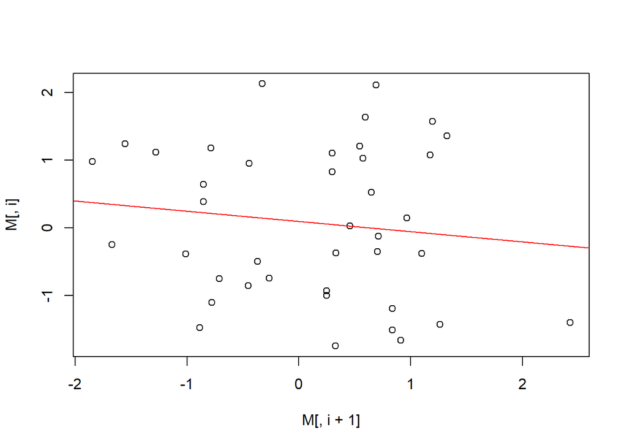

```
##
## Call:
## lm(formula = M[, i] ~ M[, i + 1])
##
## Residuals:
##     Min      1Q  Median      3Q     Max
## -2.1011 -0.7262  0.2596  0.5503  2.1698
##
## Coefficients:
##             Estimate Std. Error t value Pr(>|t|)
## (Intercept)   0.1231     0.1514   0.813    0.421
## M[, i + 1]    0.1272     0.1476   0.862    0.394
##
## Residual standard error: 0.9559 on 38 degrees of freedom
## Multiple R-squared:  0.01916,    Adjusted R-squared:  -0.00665
## F-statistic: 0.7423 on 1 and 38 DF,  p-value: 0.3943
```

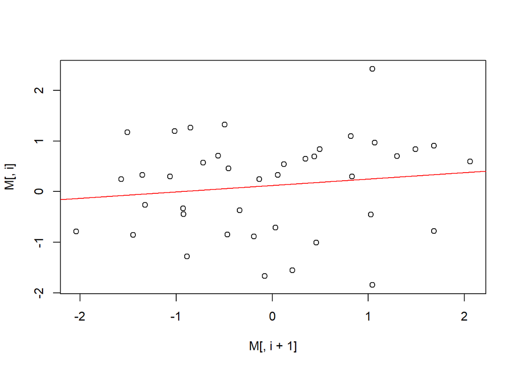

```
##
## Call:
## lm(formula = M[, i] ~ M[, i + 1])
##
## Residuals:
##      Min       1Q   Median       3Q      Max
## -2.07146 -0.88056 -0.02714  0.85287  2.08703
##
## Coefficients:
##             Estimate Std. Error t value Pr(>|t|)
## (Intercept) -0.05922    0.16504  -0.359    0.722
## M[, i + 1]  -0.12211    0.16152  -0.756    0.454
##
## Residual standard error: 1.043 on 38 degrees of freedom
## Multiple R-squared:  0.01482,    Adjusted R-squared:  -0.01111
## F-statistic: 0.5715 on 1 and 38 DF,  p-value: 0.4543
```

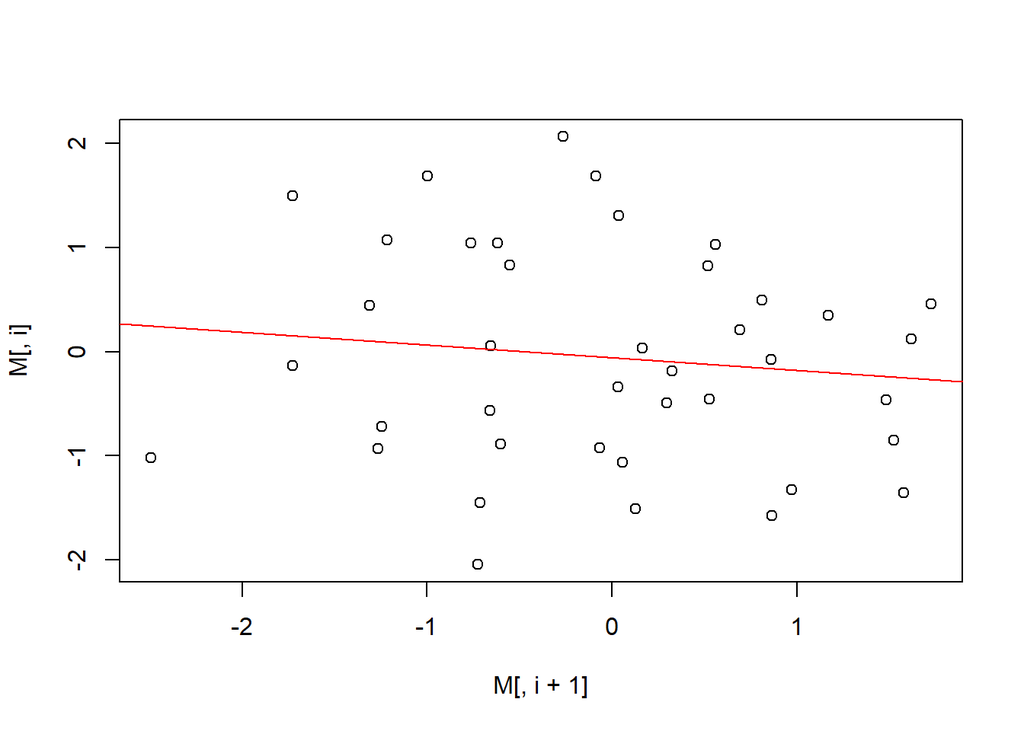

```
##
## Call:
## lm(formula = M[, i] ~ M[, i + 1])
##
## Residuals:
##      Min       1Q   Median       3Q      Max
## -2.49409 -0.65355  0.07465  0.73556  1.82037
##
## Coefficients:
##             Estimate Std. Error t value Pr(>|t|)
## (Intercept)  -0.0185     0.1688  -0.110    0.913
## M[, i + 1]   -0.1217     0.1795  -0.678    0.502
##
## Residual standard error: 1.041 on 38 degrees of freedom
## Multiple R-squared:  0.01195,    Adjusted R-squared:  -0.01405
## F-statistic: 0.4597 on 1 and 38 DF,  p-value: 0.5019
```

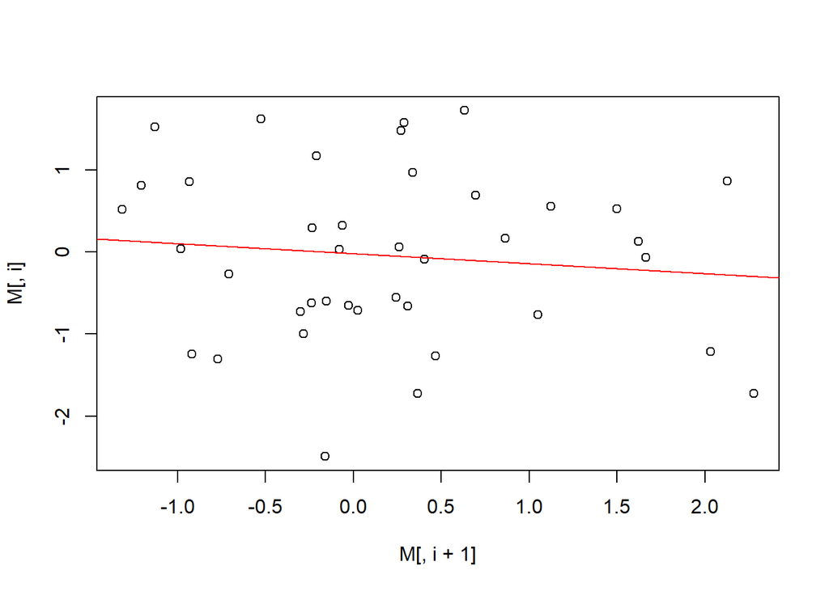

```
##
## Call:
## lm(formula = M[, i] ~ M[, i + 1])
##
## Residuals:
##      Min       1Q   Median       3Q      Max
## -1.50347 -0.55382 -0.06092  0.40663  1.98959
##
## Coefficients:
##             Estimate Std. Error t value Pr(>|t|)
## (Intercept)   0.2249     0.1484   1.516    0.138
## M[, i + 1]   -0.1390     0.1547  -0.899    0.374
##
## Residual standard error: 0.931 on 38 degrees of freedom
## Multiple R-squared:  0.02082,    Adjusted R-squared:  -0.004951
## F-statistic: 0.8079 on 1 and 38 DF,  p-value: 0.3744
```

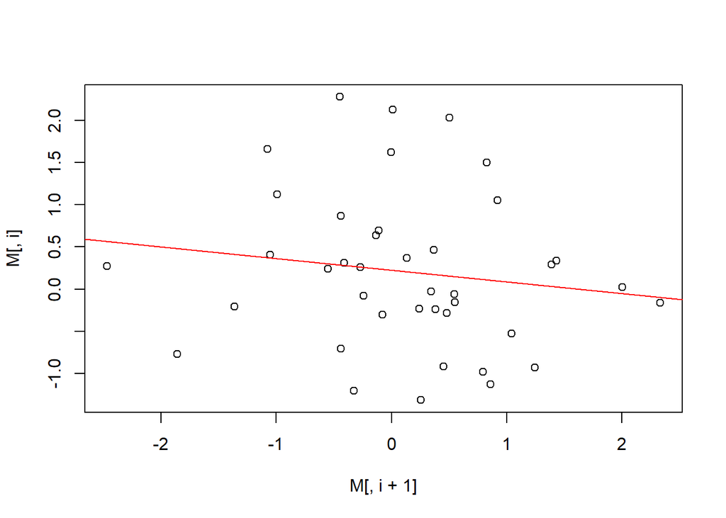

Dans notre cas, nous avons des nuages de point. On ne peut pas réellement déduire d’une quelconque dépendance des variables.

L’analyse Bivariée ne nous fait pas plus avancer.

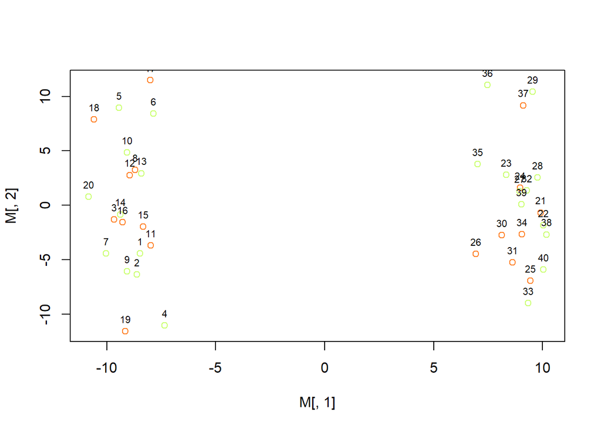

```r
res <- pcafunction(data)$PCA_component$Fi
explainKmeans(res, kmeansfunction(res, k=2))
```

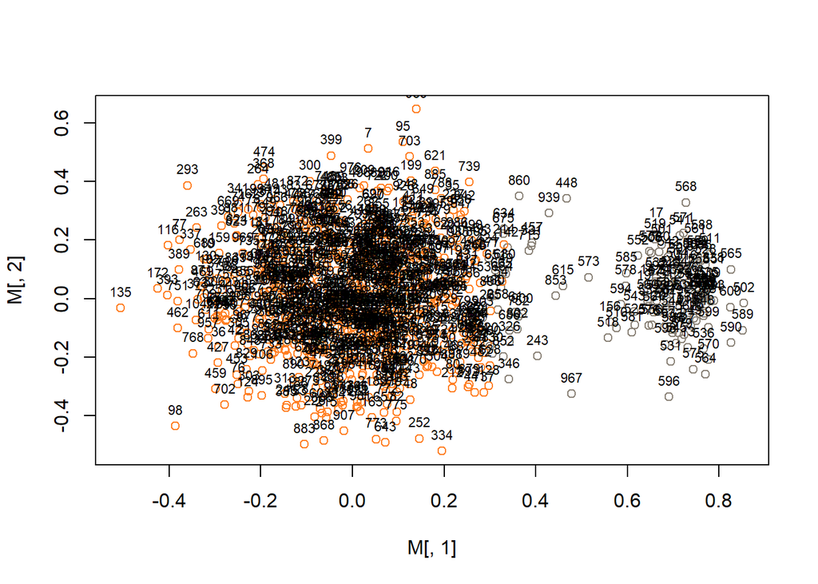

```r
res <- pcafunction(data)$PCA_component$Gi
explainKmeans(res, kmeansfunction(res, k=2))
```

Nous avons la segmentation des gènes par k-means, en revanche on ne pas interpréter car nous ne savons pas quel cluster contient les gène responsables de la maladie ou non.

```r
explainPCA(pcafunction(data, axisNumber = 2))
```

```
##
##
##  The  individuals  which have  negatively  contributed on axis  1  are :
##  i1,i2,i3,i4,i5,i6,i7,i8,i9,i10,i11,i12,i13,i14,i15,i16,i17,i18,i19,i20,
##  -------------
##
##  The  variables  which have  negatively  contributed on axis  1  are :
##  v1,v2,v8,v9,v10,v22,v24,v27,v28,v31,v32,v33,v34,v36,v37,v38,v40,v42,v44,v47,v53,v55,v56,v57,v58,v59,v65,v66,v67,v71,v72,v74,v75,v76,v77,v78,v81,v83,v84,v85,v88,v89,v91,v96,v97,v98,v99,v102,v104,v105,v106,v108,v109,v110,v111,v112,v115,v116,v117,v123,v124,v127,v130,v131,v134,v135,v137,v140,v141,v1…
##  -------------
##
##  The  individuals  which have  positively  contributed on axis  1  are :
##  i21,i22,
##  -------------
##
##  The  variables  which have  positively  contributed on axis  1  are :
##  v3,v4,v5,v6,v7,v11,v12,v13,v14,v15,v16,v17,v18,v19,v20,v21,v23,v25,v26,v29,v30,v35,v39,v41,v43,v45,v46,v48,v49,v50,v51,v52,v54,v60,v61,v62,v63,v64,v68,v69,v70,v73,v79,v80,v82,v86,v87,v90,v92,v93,v94,v95,v100,v101,v103,v107,v113,v114,v118,v119,v120,v121,v122,v125,v126,v128,v129,v132,v133,v136,v13…
##  -------------NULL
```

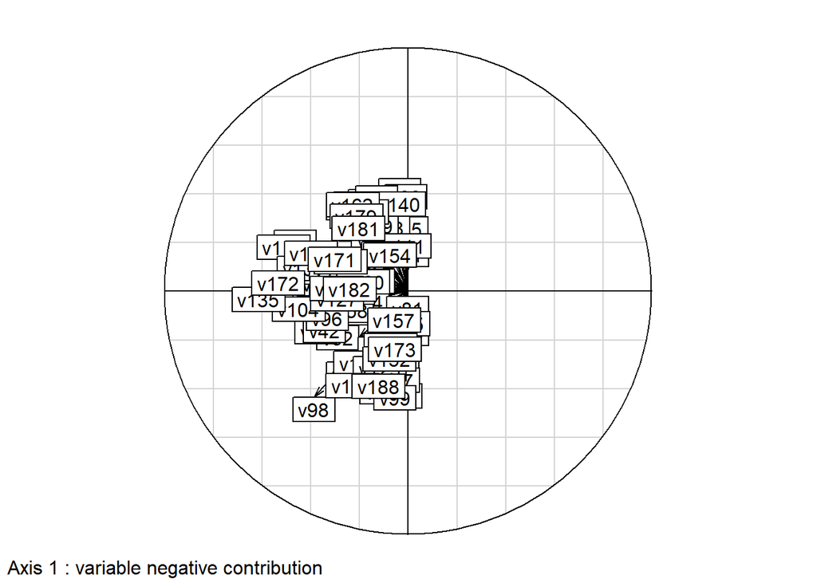

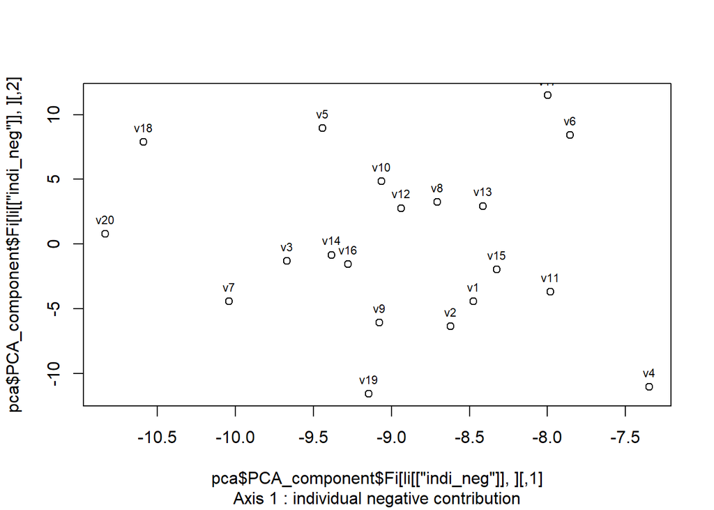

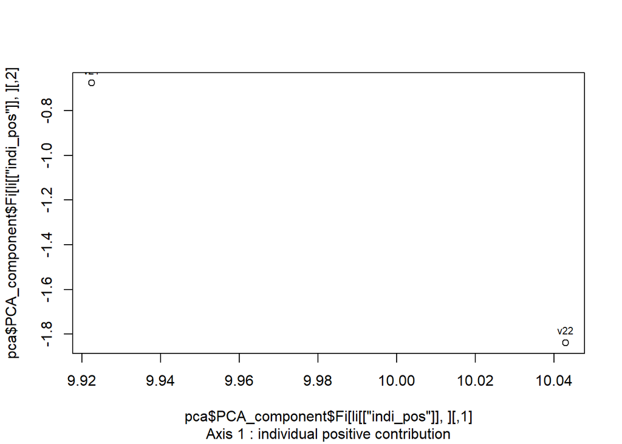

```
##
##
##  The  individuals  which have  negatively  contributed on axis  2  are :
##  i1,i2,i3,i4,i7,i9,i11,i14,
##  -------------
##
##  The  variables  which have  negatively  contributed on axis  2  are :
##  v4,v5,v11,v12,v13,v15,v16,v18,v20,v22,v24,v25,v26,v28,v30,v32,v33,v34,v36,v37,v41,v42,v43,v44,v45,v46,v47,v48,v50,v52,v58,v60,v61,v64,v67,v68,v70,v73,v76,v80,v81,v82,v84,v85,v90,v92,v93,v94,v96,v97,v98,v99,v104,v106,v113,v115,v118,v120,v123,v124,v126,v127,v128,v133,v135,v136,v138,v143,v146,v148,…
##  -------------
##
##  The  individuals  which have  positively  contributed on axis  2  are :
##  i5,i6,i8,i10,i12,i13,
##  -------------
##
##  The  variables  which have  positively  contributed on axis  2  are :
##  v1,v2,v3,v6,v7,v8,v9,v10,v14,v17,v19,v21,v23,v27,v29,v31,v35,v38,v39,v40,v49,v51,v53,v54,v55,v56,v57,v59,v62,v63,v65,v66,v69,v71,v72,v74,v75,v77,v78,v79,v83,v86,v87,v88,v89,v91,v95,v100,v101,v102,v103,v105,v107,v108,v109,v110,v111,v112,v114,v116,v117,v119,v121,v122,v125,v129,v130,v131,v132,v134,…
##  -------------NULL
```

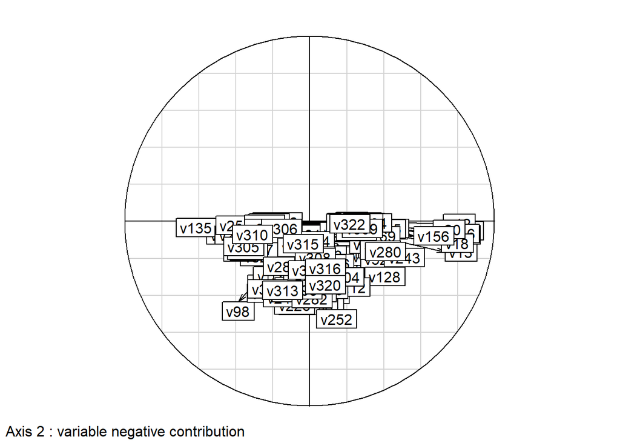

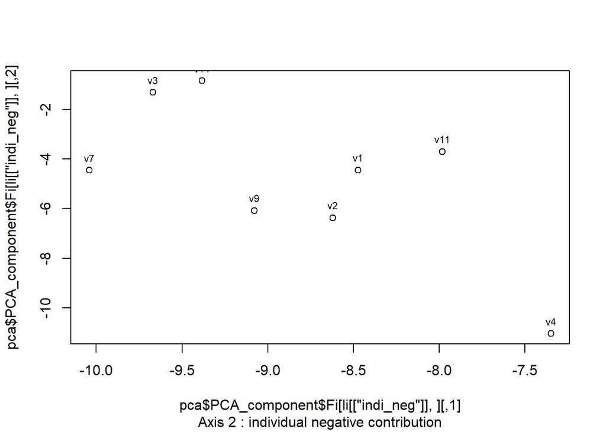

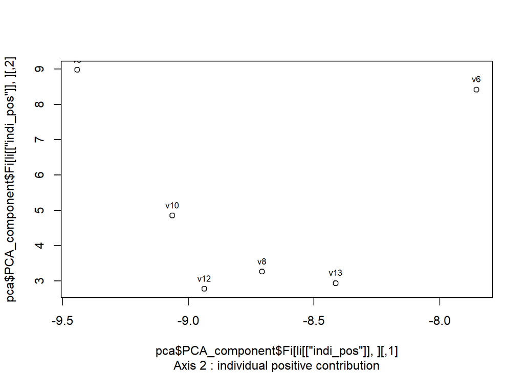

Interprétation :

Comme nous le voyons sur les cercles de corrélations, l’axe 1 est interprétable malgré le fait que de nombreuses variables soient mal représentées (à prendre avec des pincettes). Ceci est dû à la conservation d’uniquement deux axes, ce qui représente un faible pourcentage d’information captée (voir fichier test_pca.R pour les comparaisons de l’inertie)

La plupart des individus ayant participé positivement à l’axe sont les individus sains et inversement avec une contribution négative, les individus malade. On en déduit donc que les variables ayant le plus négativement contribué représentent les gènes potentiellement pathogènes, contrairement à ceux qui ont contribué positivement qui peuvent signifier soit des gènes immunisant ou neutres.

L’ACP réalisé sur ce jeu de données est difficilement interprétable dans le sens où il faudrait conserver beaucoup d’axes et donc peu réduire la dimension initiale de la matrice.